# On the Discrete Choice of Health Care Providers

Part 1: The Equivalence Between Random Utility and Gravity Model Frameworks for Discrete Choice

Health Economics

Author

John A. Graves, Ph.D.

Published

January 16, 2023

Funding for this work is graciously acknowledged from Arnold Ventures.

Suppose you are a patient requiring treatment from a hospital. Suppose further that you have three nearby hospitals (A, B and C) to choose among. What considerations do you take into account when making your treatment choice?

Models of consumer choice among competing alternatives have a long history in economics. The dominant approach remains anchored in utilitarian welfare maximization theory. Beginning with McFadden et al. (1973), economists matched (random) utility maximization-based micro-foundations with the econometric/statistical concepts of maximum likelihood to yield a tractable approach to estimating discrete choice models. These models, including the conditional logit and other valuable extensions, have served as the bedrock estimation approach for consumer and discrete choice for a generation+ of economists.

Medical geography and health services research, on the other hand, have approached the provider choice question from an additional perspective. In addition to utility maximization frameworks, another popular method conceptualizes choice as the outcome from patients weighing the “attractiveness” of different options. In the context of hospital choice, the relative attractiveness of one facility over another is based on patients weighing their own attributes (e.g., age, acuity, etc.), as well as those of the hospital (e.g., quality), against other “frictions” (e.g., travel time or distance) that influence their choices.

While these two approaches share some commonalities (e.g., the use of patient and hospital attributes, as well as distance, as key features of the underlying choice problem) they are also conceptually different. Discrete choice theory and its estimation assumptions/methods are rooted in micro-economic principles, while so-called “gravity models” are adapted from physics—specifically, a re-conceptualization of Newton’s Law of Gravitation, which states that the force between two objects (patients and hospitals) is directly proportional to their mass (i.e., their “attractiveness”) and inversely proportional to the squared distance between them.[^1]

<sup>1</sup> Gravity models do have a noteworthy lineage within economics, as well. However, their use has flourished primarily in international trade and not in consumer/discrete choice theory.

<sup>2</sup> The equivalence was also established later in the statistics literature, in Denzau, Gibbons, and Greenberg (1989), Soofi (1992) and Ggolan, Judge, and Perloff (1996).

In this blog series, we resurrect a forty-year-old paper in transportation research (Anas (1983)) to demonstrate the equivalence between the conditional logit and a gravity model.[^2] In other words, for a given set of patient and provider attributes, a conditional logit and a gravity model will yield identical predicted choice probabilities.

Bridging these two approaches proves useful because it provides a nice foundation for thinking about how to specify a discrete choice problem. In a simulated example, we’ll consider the choice of hospital in the context of privately insured patients who face higher cost-sharing if they are treated (in a nonemergency) at an out-of-network facility. Conceptually, the patient’s plan-level attributes will contribute as an additional source of “friction” or impedence son hospital choice. In other words, all else equal, a patient may prefer a nearby facility that is of high (perceived) quality. But if that facility is out-of-network, the patient may not even consider it for treatment; it may as well be 1,000 miles away.

# Information Theory and Discrete Choice

One way to conceptualize a choice problem is through information and decision theory; this approach will eventually serve as the foundation for a gravity model of discrete choice.

Information theory grew out of seminal work by Claude Shannon in 1948, and is arguably one of the most important intellectual contributions in the 20th century, if not all of human history (Shannon 1948). Information theory serves as the backbone for modern digital communication, informing how data are most efficiently compressed and transmitted across the internet, cell phones, and satellite systems.

A key concept of information theory is the idea of entropy, or the degree of uncertainty or randomness in a set of data. Shannon’s measure of entropy quantifies the amount of information in a message, data source, or (for our purposes here) choice among alternatives $h \in \text{A},\text{B},\text{C}$,

$$\mathscr{E} = -\sum_{h} P^h \log_b P^h
\tag{1}$$
where $p^k$ is the probability of observing outcome $h$, and $\log_b$ is the logarithm to the base $b$. It is common to use a base of 2 (under which entropy is measured in bits), or using the natural logarithm (i.e., base $e$; in this case entropy is measured in “nats”).

In the context of patients $j$ selecting hospitals, we will adopt a natural logarithm base and re-write Equation 1 as

$$\mathscr{E} = - \bigg ( \sum_h \sum_{j} P_j^h \log P_j^h \bigg )
\tag{2}$$

We can now think of features of the decision problem that help guide choices. These features provide information on the decision. We want to account for the pieces of information we can measure and then find the choice probabilities that maximize the remaining entropy in the decision problem.

**Code for overall entropy**

```r
set.seed(123)
P_0 = c(.05,.15,.8)
P_1 = c(.8,.15,.05)
P <- paste0(sample(c("A","B","C"),size=20,replace=TRUE,prob=P_0),collapse="")
P <- paste0(P,paste0(sample(c("A","B","C"),size=20,replace=TRUE,prob=P_1),collapse=""),collapse="")
P_ <- table(unlist(strsplit(P,"")))/40
e = -sum(P_*log(P_,2))
```

In this simple example, we have accounted for a piece of information (i.e., $X$) that reduces the overall entropy of the decision scenario.

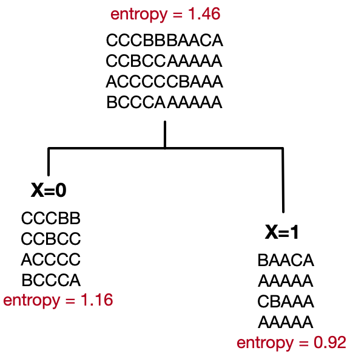

Figure 1: Decision Tree for Entropy Example

**Code for lower branches of decision tree**

```r
p0 <- substr(P,1,20)
p0_ <- table(unlist(strsplit(p0,"")))/20
e0 = -sum(p0_*log(p0_,2))

p1 <- substr(P,21,40)
p1_ <- table(unlist(strsplit(p1,"")))/20
e1 = -sum(p1_*log(p1_,2))
```

Building on this example, our modeling objective is to minimize the amount of information in the decision problem by accounting for observable features or attributes that help explain patient choices. We aim to do so subject to several constraints:

1. The sum of patient choice probabilities ($P_j^h$) must equal one (i.e., each patient must choose one hospital).
2. The sum of patient choice probabilities for each hospital must equal the total number of patients observed as treated there.
3. The expectation of the aggregate value of each attribute $k$ (i.e., $X_{jk}^h$) must equal the observed aggregate value. In Figure 1, for example, we observe 20 individuals with attribute $X=0$ and 20 with $X=1$.

```r
x <- c(rep(0, 20), rep(1, 20))
c("A", "B", "C") %>% map( ~ ({
    as.numeric(strsplit(P, "")[[1]] == .x) * x
})) %>%
    map_dbl( ~ sum(.x)) %>%
    set_names(c("A","B","C"))

P_j =
    map2(P_0,P_1,~({
    (x==0)*.x + (x==1)*.y
    }))

P_j %>% map(~({
    .x * x
})) %>%
    map(~(sum(.x)))
```

# Gravity Model

$$\underset{\left[P_j^h\right]}{\operatorname{Minimize}}-\mathscr{E}=\sum_h \sum_j P_j^h \log P_j^h$$
subject to:

$$\begin{gathered}
\sum_j P_j^h=1 ; \quad h=1 \ldots H \\
\sum_h P_j^h=\sum_h \delta_j^h ; \quad j=1 \ldots J \\
\sum_h \sum_j P_j^h X_{j k}^h=\sum_h \sum_j \delta_j^h X_{j k}^h ; \quad k=1 \ldots K .
\end{gathered}$$

```r
needed_packages <- c("tidyverse","glue","progress","here","evd","geosphere","mlogit","dfidx","janitor",
                     "Formula","hrbrthemes","survival","furrr","progressr","tictoc","mcreplicate","haven",
                     "fastDummies")

have <- rownames(installed.packages())
needed <- setdiff(needed_packages, have)

please_install <- function(pkgs, install_fun = install.packages) {

    if (length(pkgs) == 0) {
        return(invisible())
    }
    if (!interactive()) {
        stop("Please run in interactive session", call. = FALSE)
    }

    title <- paste0(
        "Ok to install these packges?\n",
        paste("* ", pkgs, collapse = "\n")
    )
    ok <- menu(c("Yes", "No"), title = title) == 1

    if (!ok) {
        return(invisible())
    }

    install_fun(pkgs,dependencies=TRUE)
}
please_install(needed)
lapply(needed_packages, require, character.only = TRUE)
```

[output not shown]

```r
options("scipen" = 100, "digits" = 5)
select <- dplyr::select

map_progress <- function(.x, .f, ..., .id = NULL) {
    # Source: https://www.jamesatkins.net/post/2020/progress-bar-in-purrrmap_df/
    .f <- purrr::as_mapper(.f, ...)
    pb <- progress::progress_bar$new(total = length(.x), force = TRUE)

    f <- function(...) {
        pb$tick()
        .f(...)
    }
    purrr::map(.x, f, ..., .id = .id)
}


map_multicore <- function(.x, .f, ..., .id = NULL) {
    .f <- purrr::as_mapper(.f, ...)
    p <- progressor(steps = length(.x))
    f <- function(...) {
        p()
        .f(...)
    }
    furrr::future_map(.x, f, ..., .id = .id)
}
```

# Data and Parameters

## HCUP Data

```r
# df <-
#     list.files("/Volumes/HPD/HCUP/Graves/sas_data_aha_linked/SID/") %>%
#     grep("^az_",.,value=TRUE) %>%
#     grep("core",.,value=TRUE) %>%
#     map(~(haven::read_sas(glue("/Volumes/HPD/HCUP/Graves/sas_data_aha_linked/SID/{.}"))))

# vars_to_include_ <- c("AHAID","ZIP","AGE","FEMALE","HCUP_ED","HCUP_OS","HISPANIC","KEY","PAY1","RACE")
# # vars_to_include <- vars_to_include_ %>% map_dbl(~(grep(glue("^{.x}$"),names(df[[1]]))))
#
# df_sid <-
#     list.files("/Volumes/HPD/HCUP/Graves/sas_data_aha_linked/SID/") %>%
#     grep("^az_",.,value=TRUE) %>%
#     grep("core",.,value=TRUE) %>%
#     map(~(haven::read_sas(glue("/Volumes/HPD/HCUP/Graves/sas_data_aha_linked/SID/{.}"),col_select = vars_to_include_))) %>%
#     pluck(1) %>%
#     filter(!is.na(AHAID) & AHAID!="")
#
# df_sid %>% write_rds("~/onedrive/Research-Arnold_Networks/data/hcup/blog-post/az-hcup.rds")

df_sid <- read_rds("~/onedrive/Research-Arnold_Networks/data/hcup/blog-post/az-hcup.rds")

hospital_ids <-
    unique(df_sid$AHAID)

df_zip <-
    read.csv(here("blog/posts/gravity/_data/ZIP-centroids_geocorr2018_2401102179.csv"),skip=1) %>%
    as_tibble() %>% clean_names() %>%
    rename(zip_x = wtd_centroid_w_longitude_degrees,
           zip_y = wtd_centroid_latitude_degrees) %>%
    mutate(zip = str_pad(zip_census_tabulation_area,width=5,pad="0",side="left")) %>%
    select(zip,zip_x,zip_y) %>%
    filter(zip %in% unique(df_sid$ZIP))
```

## AHA Data

```r
# Load hospital location data.
aha_files <- c(
    "2019" = "/Users/johngraves/Library/CloudStorage/OneDrive-VUMC/Research-AHA_Data/data/aha/annual/raw/2019/2019_ASDB/COMMA/ASPUB19.CSV"
)

df_aha <-
    aha_files %>%
    map(~(
        data.table::fread(.x) %>%
            janitor::clean_names() %>%
            mutate(system_id = ifelse(!is.na(sysid),paste0("SYS_",sysid),id)) %>%
            dplyr::filter(serv==10))) %>%
    bind_rows() %>%
    as_tibble() %>%
    filter(id %in% hospital_ids) %>%
    mutate(hosp_y = as.numeric(paste0(lat))) %>%
    mutate(hosp_x = as.numeric(paste0(long))) %>%
    select(id, hosp_x, hosp_y,mapp3,mapp8) %>%
    unique() %>%
    rename(hosp_id = id) %>%
    mutate(teaching = case_when(mapp8==1 ~ 1,
                                mapp3==1 ~ 2,
                                .default=3)) %>%
    mutate(teaching = factor(teaching,levels = 1:3, labels = c("major","minor","nonteaching"))) %>%

    select(hosp_id,hosp_x,hosp_y,teaching)
```

## Choice Sets

```r
dist_ <-
        crossing(zip = df_zip$zip ,hosp_id = df_aha$hosp_id) %>%
        as_tibble() %>%
        left_join(df_zip,"zip") %>%
        left_join(df_aha,"hosp_id") %>%
        rowwise() %>%
        mutate(dist = as.vector(distm(c(zip_x,zip_y),c(hosp_x,hosp_y), fun = distHaversine)*0.000621371)) %>%
        select(zip,hosp_id,dist) %>%
        set_names(c("zip","hosp_id","d_gh")) %>%
        data.frame() %>%
        dplyr::filter(d_gh < 200) %>%
        as_tibble()
```

```r
hosp_ <-
    df_aha %>%
    select(hosp_id, teaching)

df_choice <-
    df_sid %>%
    janitor::clean_names() %>%
    mutate(key = paste0(key)) %>%
    left_join(dist_,"zip",relationship = "many-to-many") %>%
    left_join(hosp_, "hosp_id") %>%
    mutate(choice = as.integer(ahaid==hosp_id)) %>%
    group_by(key) %>%
    filter(max(choice)==1) %>%
    mutate(closest = as.integer(d_gh == min(d_gh))) %>%
    ungroup()
```

```r
samp <- sample(df_choice$key,20000)
df_ <- df_choice %>% filter(key %in% samp) %>%
    dummy_cols("teaching") %>%
    select(choice,d_gh,teaching_nonteaching,teaching_major,zip,key,hosp_id,age,race,pay1, closest) %>%
    na.omit()

fit <- clogit(choice ~  log(d_gh^2)  + age + factor(race) + factor(pay1) + closest + teaching_nonteaching + teaching_major + strata(zip) , data = df_, method=c("efron"), robust = TRUE)
df_$pr_select <- predict(fit,type = "expected")

df_ %>%
    group_by(zip,hosp_id) %>%
    summarise(n = sum(choice), p_n = sum(pr_select)) %>%
    group_by(zip) %>%
    mutate(N = sum(n), p_N = sum(p_n)) %>%
    mutate(market_share = n/N) %>%
    mutate(p_market_share = p_n / p_N) %>%
    filter(market_share>0.01)

names(coef(fit))[-1] %>% map(~({
    c(coef(fit)[.x]/coef(fit)["log(d_gh^2)"],exp(coef(fit)[.x]))
}))
```

## References

Anas, Alex. 1983. “Discrete Choice Theory, Information Theory and the Multinomial Logit and Gravity Models.” *Transportation Research Part B: Methodological* 17 (1): 13–23. https://doi.org/10.1016/0191-2615(83)90023-1.

Denzau, Arthur T, Patrick C Gibbons, and Edward Greenberg. 1989. “Bayesian Estimation of Proportions with a Cross-Entropy Prior.” *Communications in Statistics-Theory and Methods* 18 (5): 1843–61.

Ggolan, Amos, George Judge, and Jeffrey M Perloff. 1996. “A Maximum Entropy Approach to Recovering Information from Multinomial Response Data.” *Journal of the American Statistical Association* 91 (434): 841–53.

McFadden, Daniel et al. 1973. “Conditional Logit Analysis of Qualitative Choice Behavior.”

Shannon, Claude Elwood. 1948. “A Mathematical Theory of Communication.” *The Bell System Technical Journal* 27 (3): 379–423.

Soofi, Ehsan S. 1992. “A Generalizable Formulation of Conditional Logit with Diagnostics.” *Journal of the American Statistical Association* 87 (419): 812–16.